# Mean, Medians and Log Transforms

**Lemma 1** : Given an array $X = [x_1, x_2,..., x_n]$ the mean of this array is the unique value that minimizes the sum of squares: $f(x) = \sum\limits_{i = 1}^n (x_i - x)^2$.

Proof: To find the extrema of $f$ we’ll take the first deriative and set it equal to zero:
$$f'(x) = \sum\limits_{i = 1}^n 2(x_i - x) = 0$$
so
$$\sum\limits_{i = 1}^n x_i - nx = 0$$
and
$$x = \frac{x_1 +...+x_n}{n}$$
. Since $f$ is just a second degree polynomial with positive leading term this x will be a global minima - so we’ve proved our claim - the mean minimizes the MSE. Now since the square root is a monotonic function the mean will also mimize the Root Mean Square Error and is also the *unique* value that does so.

Ok great but the metric for our competition is not RMSE nor is it RMAE but RMSLE. What does this mean? Well let’s look at the definition of RMSLE for a given array $[x_1,..., x_n]$ and a variable $a$:
$$RMSLE(x) = \sqrt{(\sum\limits_{i = 1}^n (log(x_i + 1) - log(x + 1))^2)}$$
This is very similar to RMSE! In fact one can easily check that the following holds:
$$RSMLE(x) = RMSE(log(x) + 1)$$

So remember we’re trying to find the value the minimizes the RMSLE, putting everything we’ve figured out togther we have:

**Lemma 2**: The unique value that minimizes the RMSLE is
$$exp(log(mean(X) + 1)) - 1$$

Proof: We’re trying to minimize
$$RMSLE(x) = RMSE(log(x) + 1)$$
so by lemma 1 we get that $log(x) + 1 = mean(X)$ and solving for $x$ we get that $x = exp(log(mean(X) + 1)) - 1$ and we’re done.

Ok enough theory, let’s see if this actully hold on our dataset:

```r
library(data.table)
library(Metrics)
n = 15e6
train = fread("/Users/alexpapiu/Documents/Data/Bimbo/train.csv",
              select = c("Semana", "Cliente_ID", "Producto_ID", "Demanda_uni_equil"),
              nrow = n)
```

```
Read 51.7% of 15000000 rows
Read 79.4% of 15000000 rows
Read 15000000 rows and 4 (of 11) columns from 2.980 GB file in 00:00:04
```

```r
val = train[train$Semana == 4]
train = train[train$Semana == 3]
```

```r
head(train)
```

```
   Semana Cliente_ID Producto_ID Demanda_uni_equil
1:      3      15766        1212                 3
2:      3      15766        1216                 4
3:      3      15766        1238                 4
4:      3      15766        1240                 4
5:      3      15766        1242                 3
6:      3      15766        1250                 5
```

```r
mean = mean(train$Demanda_uni_equil)
```

[output not shown]

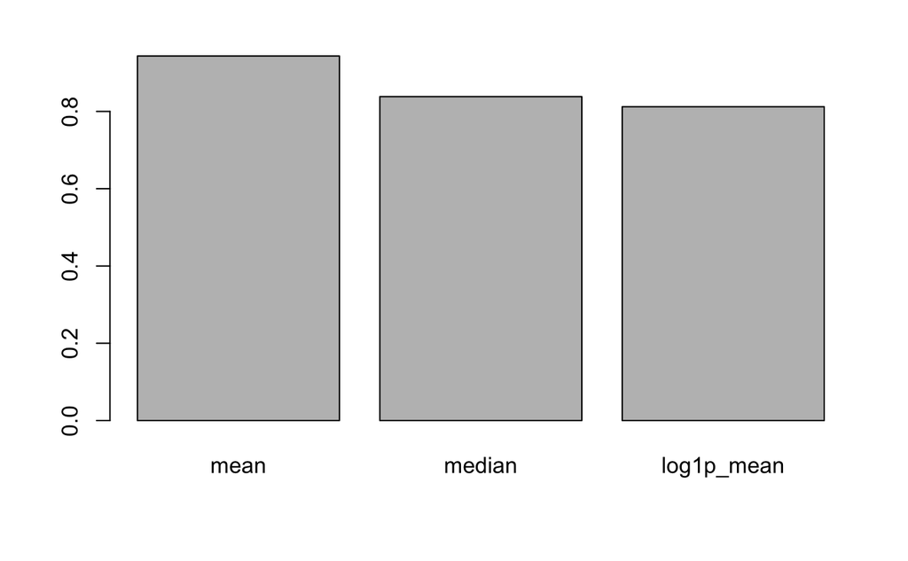

And indeed the results confirm the math (they better): the mean of the log transformed demand gets the best rmsle beating both the mean and median. The median also does much better than the mean - this is because of the demand distribution being asymetric. Note however the `expm1(mean(log1p(y)))` will *always* get a better rsmle regardless of the distribution of y.

Let’s also do this on the validation set. Here the math doesn’t guarantee anything:

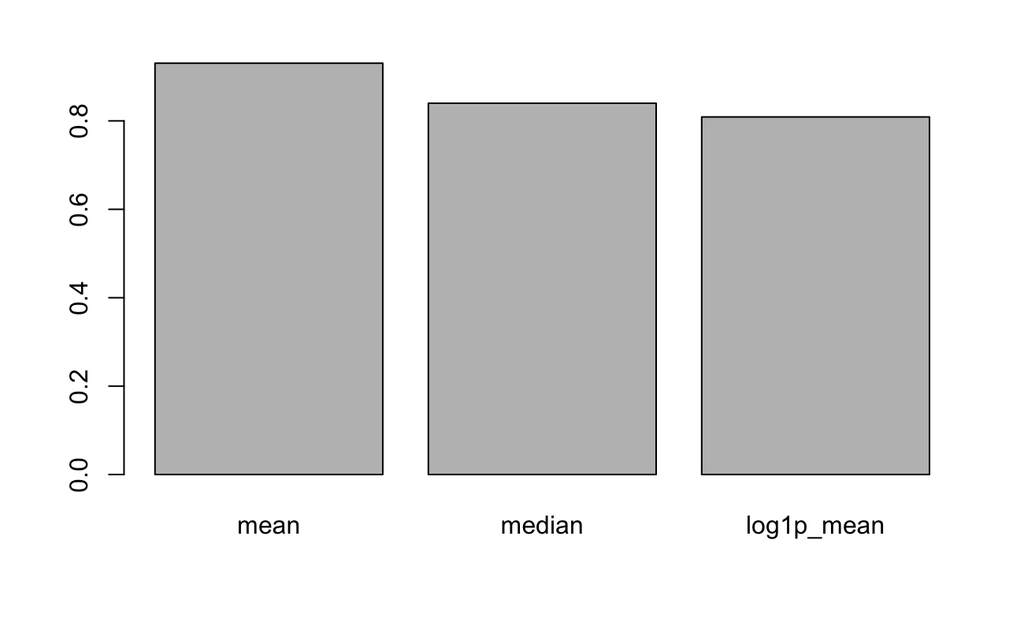

We get similar results on the validation set.

###Averaging by Group: However a global average can only get you so far. Another thing you to try is to group by some categorical variable and average for each group. There are a few scripts doing this already - especially R_medians.

```r
train[, .(mean = mean(Demanda_uni_equil),
          median = median(as.double(Demanda_uni_equil)), #data.table doesn't like ints for medians
          log1p_mean = expm1(mean(log1p(Demanda_uni_equil)))), by = .(Producto_ID)] %>%
    merge(val, all.y = TRUE, by = "Producto_ID") -> merged_val #merge with validation set by product
head(merged_val)
```

```
   Producto_ID       mean median log1p_mean Semana Cliente_ID Demanda_uni_equil
1:          53 487.333333  417.5 351.981701      4    1216931               737
2:          53 487.333333  417.5 351.981701      4    1216931               184
3:          72   4.832258    4.0   4.054935      4      49939                12
4:          72   4.832258    4.0   4.054935      4      50036                 8
5:          72   4.832258    4.0   4.054935      4      50286                 5
6:          72   4.832258    4.0   4.054935      4      50352                11
```

Now let’s compute the rmsle on the validation set and visualize the results again. We have 52 NA’s that we will just exclude:

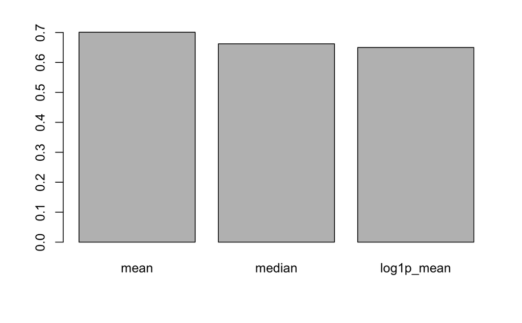

And the math pushes us in the right direction once again.